# Student Dropout Prediction System

## 📌 Key Concepts

### 🏗️ Architecture vs Framework

| Architecture | Framework |
| --- | --- |
| Blueprint or overall design of a system. | Pre-built structure and tools used for development. |
| Defines components and interactions. | Provides reusable code and guidelines. |
| Example: Microservices Architecture | Example: Django, React, Spring Boot |

### 🤖 Generative AI (GenAI)

Generative AI is a branch of Artificial Intelligence that creates new content such as text, images, audio, videos, or code by learning patterns from existing data.

### 🎭 Deepfake

Deepfake is AI-generated synthetic media where a person's face, voice, or appearance is realistically altered or replaced to create fake but convincing content.

### ⚙️ Automation vs AI

| Automation | Artificial Intelligence |
| --- | --- |
| Follows predefined rules. | Learns patterns from data. |
| Does not adapt. | Can improve over time. |
| Rule-based. | Data-driven. |
| Example: Auto email replies. | Example: ChatGPT, Recommendation Systems. |

### 💻 Interpreted vs Compiled Languages

- **Compiled Languages:** Entire source code is translated before execution. (C, C++)
- **Interpreted Languages:** Code is translated line-by-line during execution. (Python, JavaScript)

# 🎓 Student Dropout Prediction System

### 📖 Initial Problem Statement

Many students discontinue their studies before graduation. The university wants to reduce dropout rates and approaches an AI team to develop a prediction system.

**Challenge:** The statement is not yet a well-defined AI problem.

## 🔍 Step 1: Understand the Business Problem

### Questions for Academic Department

- Current dropout ratio?
- Since when has it increased?
- Which departments are affected?

### Questions for Student Welfare Team

- What interventions currently exist?
- How much time is available before intervention?

### Questions for Management

- Why is this important?
- What are the financial and social impacts?

### 📊 University Responses

- Current dropout rate = **18%**
- Desired dropout rate = **10%**
- Most dropouts occur during the **first year**
- Counsellors can support only **200 students/semester**
- Early identification improves retention

## 🎯 Step 2: Define the Problem Precisely

### ❌ Poor Problem Statement

Students are dropping out.

### ✅ Better Problem Statement

Identify first-year students who are at high risk of dropping out at least one semester before withdrawal so that counsellors can intervene.

| Question | Answer |
| --- | --- |
| Who? | First-year students |
| What? | Predict dropout risk |
| When? | One semester in advance |
| Why? | Enable early intervention |
| Outcome? | Reduce dropout rate |

## 🤔 Step 3: Is AI Really Needed?

If a simple rule solves the problem, AI may not be required.

### Use AI When:

- Patterns are complex
- Multiple factors interact
- Manual rules are insufficient

### Why AI is Needed Here?

- Attendance
- Academic performance
- Financial background
- Student engagement
- Course difficulty
- Psychological indicators

## 👥 Step 4: Identify Stakeholders

### Primary Stakeholders

- First-year students
- Academic counsellors

### Secondary Stakeholders

- Faculty
- Department Heads
- University Administration
- Parents

### Technical Stakeholders

- IT Department
- Data Analysts
- Development Team

## ⚙️ Step 5: Define the AI Task

### Machine Learning Formulation

- **Classification:** Dropout (Yes / No)
- **Risk Scoring:** Probability (0–100%)
- **Ranking:** Top 200 students needing intervention

## 📈 Step 6: Define Success Metrics

- Accuracy
- Precision
- Recall
- F1 Score
- ROC-AUC

## 🚧 Step 7: Constraints

### Operational Constraints

- Counsellors can support only 200 students per semester.

### Time Constraints

- Prediction must happen before next semester registration.

### Data Constraints

- Mental health indicators may be unavailable.
- Family circumstances may be unknown.
- Financial records may be incomplete.

### Ethical Constraints

- Students should not be harmed.
- Avoid bias and discrimination.
- Provide appeal mechanisms.
- Avoid stigmatizing students.

## ⚠️ Step 8: Assumptions and Risks

### Assumptions

- Historical data reflects future trends.
- Attendance records are accurate.
- Counsellors act on recommendations.

### Risks

- Missing data
- Biased historical decisions
- Changes in academic policies
- Unexpected events affecting dropout patterns

# 📝 4W Problem Canvas

## 👤 WHO?

- First-year students at risk of dropping out
- Academic counsellors

## ❓ WHAT?

- Current dropout rate: 18%
- Target dropout rate: 10%
- Students identified too late
- Need early intervention

## 📍 WHERE?

- Departments with high dropout rates
- Student support systems
- Academic processes

## 🎯 WHY?

### For Students

- Continue education
- Increase confidence
- Improve career opportunities

### For University

- Improve retention
- Protect reputation
- Reduce revenue loss

### For Society

- Reduce resource wastage
- Develop a skilled workforce

## ✅ Final AI Problem Statement

Identify first-year students who are at high risk of dropping out at least one semester before withdrawal, enabling counsellors to provide timely intervention and reduce the dropout rate from 18% to 10%.

# 📥 Data Acquisition

The first step of this project is to acquire a dataset that represents various academic, demographic, and personal factors influencing student performance. Since a real-world dataset containing all the required attributes was not publicly available, a **synthetic dataset** was generated using **NumPy** and **Pandas**.

## 🌸 Synthetic Data Generation

The generated dataset contains the following features:

| 📌 Feature | 📖 Description | 🎲 Generated Values |
| --- | --- | --- |
| **Age** | Student's age | 17 – 25 years |
| **Gender** | Gender of student | Male / Female |
| **Attendance** | Attendance percentage | 40% – 100% |
| **CGPA** | Academic performance | 4.50 – 10.00 |
| **Backlogs** | Number of pending subjects | 0 – 7 |
| **FamilyIncome** | Annual family income | ₹1,50,000 – ₹1,20,00,000 |
| **StudyHours** | Daily study hours | 0.5 – 8 hours |
| **Scholarship** | Scholarship status | 0 = No, 1 = Yes |
| **InternetAccess** | Internet availability | 0 = No, 1 = Yes |
| **Hostel** | Hostel residence | 0 = No, 1 = Yes |
| **MentalStress** | Stress level | 1 – 10 |
| **PartTimeJob** | Part-time employment | 0 = No, 1 = Yes |

### ✨ Why Synthetic Data?

- 📊 Simulates realistic student information.
- 🔄 Enables reproducible experiments using a fixed random seed.
- 🧩 Provides sufficient diversity for machine learning model development.
- 🚀 Eliminates privacy and confidentiality concerns associated with real student records.

```python
import pandas as pd
import numpy as np
from sklearn.model_selection import train_test_split
```

```python
np.random.seed(42)
n = 100

df = pd.DataFrame({
    "Age": np.random.randint(17,26, n),
    "Gender": np.random.choice(["Male","Female"], n),
    "Attendance": np.random.randint(40, 101, n),
    "CGPA": np.round(np.random.uniform(4.5, 10, n),2),
    "Backlogs":np.random.randint(0,8,n),
    "FamilyIncome": np.random.randint(150000, 12000000, n),
    "StudyHours": np.round(np.random.uniform(0.5,8,n),1),
    "Scholarship": np.random.choice([0,1],n, p=[0.7,0.3]),
    "InternetAccess": np.random.choice([0,1],n, p=[0.15,0.85]),
    "Hostel": np.random.choice([0,1],n),
    "MentalStress": np.random.randint(1,11,n),
    "PartTimeJob": np.random.choice([0,1],n, p=[0.75,0.25])
})
```

```python
df
```

|  | Age | Gender | Attendance | CGPA | Backlogs | FamilyIncome | StudyHours | Scholarship | InternetAccess | Hostel | MentalStress | PartTimeJob |
| --- | --- | --- | --- | --- | --- | --- | --- | --- | --- | --- | --- | --- |
| 0 | 23 | Male | 97 | 7.98 | 5 | 1257677 | 5.0 | 1 | 0 | 1 | 5 | 1 |
| 1 | 20 | Male | 91 | 6.36 | 2 | 5888852 | 4.7 | 0 | 1 | 1 | 10 | 0 |
| 2 | 24 | Male | 51 | 6.42 | 3 | 438790 | 2.1 | 1 | 0 | 1 | 1 | 0 |
| 3 | 21 | Female | 78 | 8.49 | 4 | 5234921 | 7.6 | 0 | 1 | 1 | 6 | 0 |
| 4 | 23 | Male | 41 | 9.43 | 0 | 11183097 | 6.4 | 1 | 1 | 0 | 6 | 1 |
| ... | ... | ... | ... | ... | ... | ... | ... | ... | ... | ... | ... | ... |
| 95 | 19 | Male | 87 | 6.08 | 4 | 8964131 | 1.1 | 0 | 1 | 1 | 2 | 0 |
| 96 | 24 | Female | 51 | 7.75 | 6 | 3749865 | 7.1 | 0 | 1 | 1 | 5 | 0 |
| 97 | 22 | Male | 44 | 4.67 | 3 | 5532287 | 4.6 | 0 | 1 | 1 | 1 | 0 |
| 98 | 19 | Female | 76 | 4.71 | 0 | 8140340 | 1.7 | 0 | 0 | 1 | 7 | 0 |
| 99 | 17 | Male | 71 | 9.02 | 5 | 1189458 | 3.6 | 0 | 1 | 1 | 1 | 0 |

100 rows × 12 columns

```python
# Low attendance | Low CGPA | Many Backlogs | High Stress
risk = (
    (df["Attendance"] < 65).astype(int) +
    (df["CGPA"]<6.0).astype(int) +
    (df["Backlogs"]>= 3).astype(int) +
    (df["MentalStress"]>=8).astype(int) +
    (df["StudyHours"]< 2).astype(int)
)

df["Dropout"] = np.where(risk>= 3,1,0)
```

```python
#df["Dropout"]
```

```python
df.head()
```

|  | Age | Gender | Attendance | CGPA | Backlogs | FamilyIncome | StudyHours | Scholarship | InternetAccess | Hostel | MentalStress | PartTimeJob | Dropout |
| --- | --- | --- | --- | --- | --- | --- | --- | --- | --- | --- | --- | --- | --- |
| 0 | 23 | Male | 97 | 7.98 | 5 | 1257677 | 5.0 | 1 | 0 | 1 | 5 | 1 | 0 |
| 1 | 20 | Male | 91 | 6.36 | 2 | 5888852 | 4.7 | 0 | 1 | 1 | 10 | 0 | 0 |
| 2 | 24 | Male | 51 | 6.42 | 3 | 438790 | 2.1 | 1 | 0 | 1 | 1 | 0 | 0 |
| 3 | 21 | Female | 78 | 8.49 | 4 | 5234921 | 7.6 | 0 | 1 | 1 | 6 | 0 | 0 |
| 4 | 23 | Male | 41 | 9.43 | 0 | 11183097 | 6.4 | 1 | 1 | 0 | 6 | 1 | 0 |

```python
X = df.drop("Dropout",axis=1)
y = df["Dropout"]
X
```

|  | Age | Gender | Attendance | CGPA | Backlogs | FamilyIncome | StudyHours | Scholarship | InternetAccess | Hostel | MentalStress | PartTimeJob |
| --- | --- | --- | --- | --- | --- | --- | --- | --- | --- | --- | --- | --- |
| 0 | 23 | Male | 97 | 7.98 | 5 | 1257677 | 5.0 | 1 | 0 | 1 | 5 | 1 |
| 1 | 20 | Male | 91 | 6.36 | 2 | 5888852 | 4.7 | 0 | 1 | 1 | 10 | 0 |
| 2 | 24 | Male | 51 | 6.42 | 3 | 438790 | 2.1 | 1 | 0 | 1 | 1 | 0 |
| 3 | 21 | Female | 78 | 8.49 | 4 | 5234921 | 7.6 | 0 | 1 | 1 | 6 | 0 |
| 4 | 23 | Male | 41 | 9.43 | 0 | 11183097 | 6.4 | 1 | 1 | 0 | 6 | 1 |
| ... | ... | ... | ... | ... | ... | ... | ... | ... | ... | ... | ... | ... |
| 95 | 19 | Male | 87 | 6.08 | 4 | 8964131 | 1.1 | 0 | 1 | 1 | 2 | 0 |
| 96 | 24 | Female | 51 | 7.75 | 6 | 3749865 | 7.1 | 0 | 1 | 1 | 5 | 0 |
| 97 | 22 | Male | 44 | 4.67 | 3 | 5532287 | 4.6 | 0 | 1 | 1 | 1 | 0 |
| 98 | 19 | Female | 76 | 4.71 | 0 | 8140340 | 1.7 | 0 | 0 | 1 | 7 | 0 |
| 99 | 17 | Male | 71 | 9.02 | 5 | 1189458 | 3.6 | 0 | 1 | 1 | 1 | 0 |

100 rows × 12 columns

```python
# y
X = pd.get_dummies(X, drop_first=True)
```

```python
X
```

|  | Age | Attendance | CGPA | Backlogs | FamilyIncome | StudyHours | Scholarship | InternetAccess | Hostel | MentalStress | PartTimeJob | Gender_Male |
| --- | --- | --- | --- | --- | --- | --- | --- | --- | --- | --- | --- | --- |
| 0 | 23 | 97 | 7.98 | 5 | 1257677 | 5.0 | 1 | 0 | 1 | 5 | 1 | True |
| 1 | 20 | 91 | 6.36 | 2 | 5888852 | 4.7 | 0 | 1 | 1 | 10 | 0 | True |
| 2 | 24 | 51 | 6.42 | 3 | 438790 | 2.1 | 1 | 0 | 1 | 1 | 0 | True |
| 3 | 21 | 78 | 8.49 | 4 | 5234921 | 7.6 | 0 | 1 | 1 | 6 | 0 | False |
| 4 | 23 | 41 | 9.43 | 0 | 11183097 | 6.4 | 1 | 1 | 0 | 6 | 1 | True |
| ... | ... | ... | ... | ... | ... | ... | ... | ... | ... | ... | ... | ... |
| 95 | 19 | 87 | 6.08 | 4 | 8964131 | 1.1 | 0 | 1 | 1 | 2 | 0 | True |
| 96 | 24 | 51 | 7.75 | 6 | 3749865 | 7.1 | 0 | 1 | 1 | 5 | 0 | False |
| 97 | 22 | 44 | 4.67 | 3 | 5532287 | 4.6 | 0 | 1 | 1 | 1 | 0 | True |
| 98 | 19 | 76 | 4.71 | 0 | 8140340 | 1.7 | 0 | 0 | 1 | 7 | 0 | False |
| 99 | 17 | 71 | 9.02 | 5 | 1189458 | 3.6 | 0 | 1 | 1 | 1 | 0 | True |

100 rows × 12 columns

# 📊 Data Exploration

### 🔍 Understanding the Dataset

Data Exploration is the first and one of the most important stages of any Machine Learning project. In this phase, we examine the structure, quality, and characteristics of the student dataset before performing preprocessing or model building.

### 🎯 Objectives

- Understand the dataset structure
- Identify feature names and data types
- Analyze the target variable (**Dropout Status**)
- Detect missing values and duplicate records
- Generate descriptive statistics
- Explore categorical and numerical features
- Identify class imbalance and potential outliers

## 📈 Exploratory Analysis Includes

✅ Dataset Shape (Rows & Columns)

✅ First & Last Five Records

✅ Target Variable Distribution

✅ Correlation Analysis

### 💡 Why Data Exploration?

Understanding the dataset helps uncover hidden patterns, identify data quality issues, and make informed preprocessing decisions. Proper exploration leads to better feature engineering, improved model performance, and more reliable predictions for identifying students at risk of dropping out.

```python
import matplotlib.pyplot as plt
import seaborn as sns

# Professional Light Theme
plt.style.use('default')
sns.set_theme(style="whitegrid", font_scale=1.1)

# Professional Color Palette
colors = ["#5B8FF9", "#61DDAA", "#65789B", "#F6BD16", "#7262FD"]
```

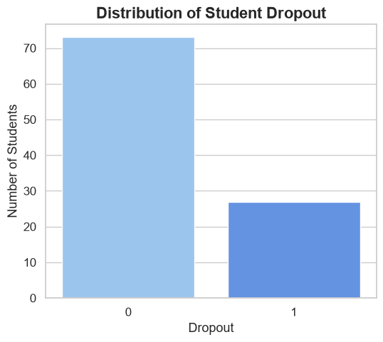

```python
plt.figure(figsize=(6,5))

sns.countplot(
    data=df,
    x="Dropout",
    hue="Dropout",
    palette=["#8EC5FC", "#4F8EF7"],
    legend=False
)

plt.title("Distribution of Student Dropout", fontsize=16, weight="bold")
plt.xlabel("Dropout")
plt.ylabel("Number of Students")

plt.show()
```

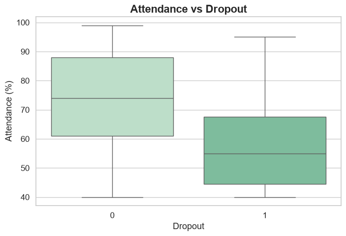

```python
plt.figure(figsize=(8,5))

ax = sns.boxplot(
    data=df,
    x="Dropout",
    y="Attendance",
    hue="Dropout",
    palette=["#B7E4C7", "#74C69D"]
)

# Remove legend
if ax.get_legend() is not None:
    ax.get_legend().remove()

plt.title("Attendance vs Dropout", fontsize=16, weight="bold")
plt.xlabel("Dropout")
plt.ylabel("Attendance (%)")

plt.show()
```

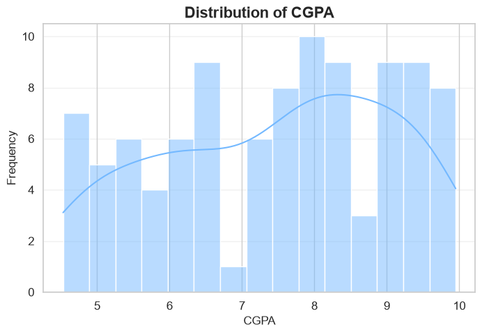

```python
plt.figure(figsize=(8,5))

sns.histplot(
    data=df,
    x="CGPA",
    bins=15,
    kde=True,
    color="#74B9FF",
    edgecolor="white",
    linewidth=1
)

plt.title("Distribution of CGPA", fontsize=16, fontweight="bold")
plt.xlabel("CGPA", fontsize=12)
plt.ylabel("Frequency", fontsize=12)

plt.grid(axis="y", alpha=0.3)

plt.show()
```

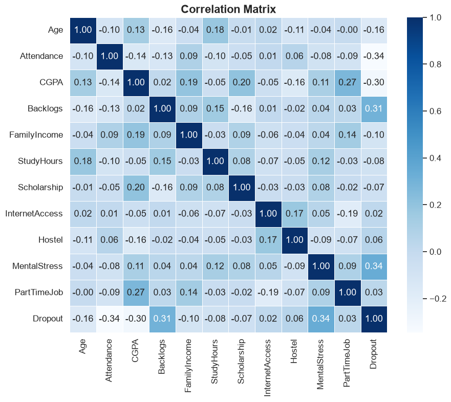

```python
plt.figure(figsize=(10,8))

sns.heatmap(
    df.corr(numeric_only=True),
    annot=True,
    cmap="Blues",
    linewidths=0.5,
    fmt=".2f"
)

plt.title("Correlation Matrix", fontsize=16, weight="bold")

plt.show()
```

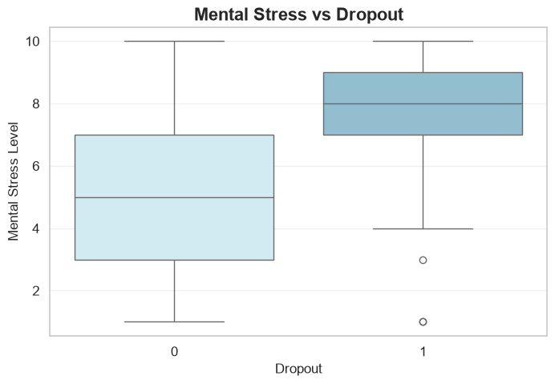

```python
plt.figure(figsize=(8,5))

sns.boxplot(
    data=df,
    x="Dropout",
    y="MentalStress",
    hue="Dropout",
    palette=["#CDEDF6", "#89C2D9"],
    legend=False
)

plt.title("Mental Stress vs Dropout", fontsize=16, fontweight="bold")
plt.xlabel("Dropout", fontsize=12)
plt.ylabel("Mental Stress Level", fontsize=12)

plt.grid(axis='y', alpha=0.3)

plt.show()
```

```python
X_train, X_test, y_train, y_test =  train_test_split(
    X,
    y,
    test_size = 0.2,
    random_state = 41,
    stratify=y
)
```

```python
X_train.shape
```

```
(80, 12)
```

```python
X_test.shape
```

```
(20, 12)
```

```python
y_train.shape
```

```
(80,)
```

```python
y_test.shape
```

```
(20,)
```

# 🤖 Data Modelling (Training)

## 🌸 Model Training

The dataset is divided into **training** and **testing** sets. The training dataset is used to fit each classification algorithm, enabling the models to identify patterns and relationships within the data.

The following classification algorithms were trained:

| 🤖 Algorithm | 📖 Purpose |
| --- | --- |
| **Logistic Regression** | Linear classification model for binary prediction. |
| **K-Nearest Neighbors (KNN)** | Classifies samples based on the nearest neighboring observations. |
| **Decision Tree** | Learns decision rules by recursively splitting the dataset. |
| **Random Forest** | Ensemble of multiple decision trees for improved accuracy and robustness. |
| **Support Vector Machine (SVM)** | Finds the optimal decision boundary that maximizes class separation. |
| **Gaussian Naive Bayes** | Probabilistic classifier based on Bayes' Theorem with Gaussian distribution assumptions. |
| **XGBoost Classifier** | Gradient boosting algorithm that builds highly accurate ensemble models. |

### ⚙️ Training Workflow

The following steps were performed for every classification model:

- 📂 Load the machine learning algorithm.
- 🎓 Train the model using the **training dataset (`X_train`, `y_train`)**.
- 🧠 Learn the underlying patterns from the input features.
- 🔮 Generate predictions for the unseen **testing dataset (`X_test`)**.
- 📊 Store the predicted results for model evaluation.

### ✨ Why Train Multiple Models?

- 📈 Compare the performance of different algorithms.
- 🎯 Identify the model with the highest predictive capability.
- ⚖️ Evaluate both simple and ensemble learning techniques.
- 🚀 Select the most suitable classifier for the final deployment.

```python
from sklearn.linear_model import LogisticRegression
from sklearn.neighbors import KNeighborsClassifier
from sklearn.tree import DecisionTreeClassifier
from sklearn.ensemble import RandomForestClassifier
from sklearn.svm import SVC
from xgboost import XGBClassifier
from sklearn.naive_bayes import GaussianNB
```

```python
models = {
    "Logistic Regression": LogisticRegression(max_iter=1000),
    "KNN":KNeighborsClassifier(),
    "Decision Tree": DecisionTreeClassifier(),
    "Random Forest": RandomForestClassifier(),
    "SVM": SVC(),
    "XGBoost": XGBClassifier(),
    "Naive Bayes": GaussianNB()
}
```

# 📊 Model Evaluation & Testing

## 🌸 Performance Evaluation

Each trained classifier predicts the class labels for the testing data. Whenever available, prediction probabilities are also generated to calculate probability-based evaluation metrics such as **ROC-AUC**.

The following evaluation metrics were computed for every model:

| 📈 Metric | 📖 Description |
| --- | --- |
| **Accuracy** | Measures the overall percentage of correctly classified instances. |
| **Precision** | Indicates how many predicted positive instances are actually correct. |
| **Recall** | Measures the model's ability to correctly identify positive instances. |
| **F1-Score** | Harmonic mean of Precision and Recall, providing a balanced performance measure. |
| **ROC-AUC Score** | Evaluates the model's ability to distinguish between different classes across various thresholds. |

### ⚙️ Evaluation Workflow

For every trained classification model, the following steps were performed:

- 📥 Load the trained model.
- 🔮 Predict class labels using the testing dataset.
- 📊 Generate prediction probabilities (where supported).
- 📈 Calculate Accuracy, Precision, Recall, F1-Score, and ROC-AUC.
- 📋 Store the evaluation results for comparison across all models.

### ✨ Why Use Multiple Evaluation Metrics?

- 🎯 Accuracy alone may not fully reflect model performance.
- ⚖️ Precision and Recall provide deeper insights into classification quality.
- 📊 F1-Score balances false positives and false negatives.
- 🚀 ROC-AUC measures the model's discrimination capability across different decision thresholds.
- 🏆 Comparing multiple metrics helps identify the most reliable and robust classifier.

```python
from sklearn.metrics import (
    accuracy_score,
    precision_score,
    recall_score,
    f1_score,
    roc_auc_score
)

results = []

for name, model in models.items():

    # Train
    model.fit(X_train, y_train)

    # Predict class labels
    y_pred = model.predict(X_test)

    # Predict probabilities
    if hasattr(model, "predict_proba"):
        y_prob = model.predict_proba(X_test)[:, 1]
    else:
        # SVM without probability=True
        y_prob = y_pred

    results.append({
        "Model": name,
        "Accuracy": accuracy_score(y_test, y_pred),
        "Precision": precision_score(y_test, y_pred),
        "Recall": recall_score(y_test, y_pred),
        "F1 Score": f1_score(y_test, y_pred),
        "ROC AUC": roc_auc_score(y_test, y_prob)
    })
```

```python
result_df = pd.DataFrame(results)
result_df = result_df.sort_values(
    by="Accuracy",
    ascending = False
)
result_df
```

|  | Model | Accuracy | Precision | Recall | F1 Score | ROC AUC |
| --- | --- | --- | --- | --- | --- | --- |
| 3 | Random Forest | 0.90 | 1.000000 | 0.6 | 0.750000 | 0.946667 |
| 2 | Decision Tree | 0.85 | 0.750000 | 0.6 | 0.666667 | 0.766667 |
| 0 | Logistic Regression | 0.85 | 0.666667 | 0.8 | 0.727273 | 0.920000 |
| 5 | XGBoost | 0.85 | 0.750000 | 0.6 | 0.666667 | 0.920000 |
| 4 | SVM | 0.75 | 0.000000 | 0.0 | 0.000000 | 0.500000 |
| 6 | Naive Bayes | 0.75 | 0.000000 | 0.0 | 0.000000 | 0.466667 |
| 1 | KNN | 0.65 | 0.250000 | 0.2 | 0.222222 | 0.760000 |